# Your BBOB Fitness Function May Be Burning More Energy Than You Think

Key findings from *Measuring Energy Consumption of BBOB Fitness Functions* (EvoStar 2025)

Juan J. Merelo-Guervós, Gustavo Romero López, Mario García-Valdez

2025-04-25

## The Hidden Cost of Evaluating Solutions

Every time an evolutionary algorithm evaluates a candidate solution, it runs a **fitness function** — usually dozens of thousands of times per experiment, and thousands of experiments over a research career. We rarely stop to ask: *how much energy does that actually cost?*

In a world where [software is responsible for a growing share of global electricity consumption](https://doi.org/10.1007/978-3-031-90065-5_15), understanding and minimising the energy footprint of our algorithms is no longer optional. It is part of good engineering — and good science.

In our paper published at [EvoStar 2025](https://link.springer.com/chapter/10.1007/978-3-031-90065-5_15), we asked a deceptively simple question:

> **Among the standard BBOB floating-point fitness functions, how much energy does each one consume — and do the representation choices we make (precision, data structure) actually matter?**

The answers were surprising.

## How We Measured It

We used [**pinpoint**](https://github.com/osmhpi/pinpoint), a multiplatform tool that hooks into the CPU’s built-in power sensors (Intel/AMD RAPL) and reports the total energy consumed by the *package* — CPU cores plus memory — during a process run. This is a hardware-level measurement, not a simulation.

The measurement procedure:

1. **Baseline**: generate 40 000 random floating-point chromosomes and record the energy (`PKG`, in Joules) consumed. This represents the unavoidable overhead of just *having* a population.
2. **Function evaluation**: apply each BBOB fitness function to the same 40 000 chromosomes and record energy again.
3. **Delta**: subtract the baseline mean to isolate the energy cost of the function itself (`ΔE = PKG_function − mean(PKG_baseline)`).

We repeated every configuration **30 times** on a dedicated AMD Ryzen 9 3950X machine (Ubuntu 20.04, g++ 10.5, `-O3 -march=native -flto`), varying:

- **Precision**: `float` (32-bit) vs `double` (64-bit)
- **Chromosome size**: 128, 256 and 512 dimensions
- **Data structure**: variable-size `std::vector` vs fixed-size `std::array`

Ten BBOB functions were chosen to span all structural categories: `sphere`, `rastrigin`, `rosenbrock`, `discus`, `bent_cigar`, `different_powers`, `sharp_ridge`, `schaffers`, `schwefel`, and `katsuura`.

## Finding 1: The Energy Landscape Spans Orders of Magnitude

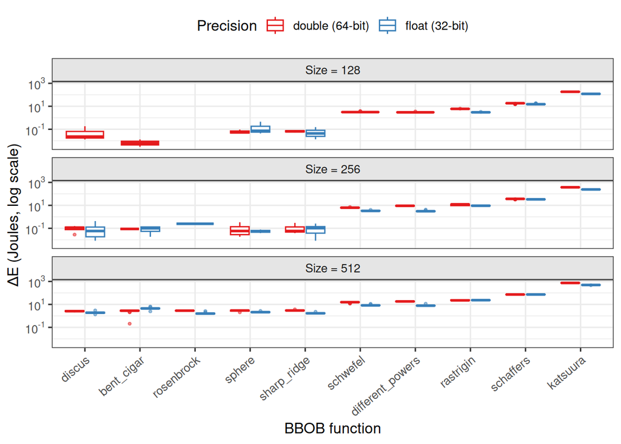

**Figure 1.** Median energy consumption (ΔE, Joules, log scale) of each BBOB fitness function for 40 000 evaluations, by chromosome size and floating-point precision. Functions are ranked by their median energy at size 512 with double precision. The y-axis is on a base-10 log scale — each tick is a 10× increase.

To put that in concrete terms:

Table 1. Energy cost per batch of 40 000 evaluations at chromosome size 512.

| Function | Precision | Median ΔE (J) | 75th pctile ΔE (J) |
| --- | --- | --- | --- |
| discus | double (64-bit) | 2.5883 | 2.8358 |
| bent_cigar | double (64-bit) | 2.7683 | 2.9883 |
| rosenbrock | double (64-bit) | 2.8583 | 2.9583 |
| sphere | double (64-bit) | 2.8583 | 3.0658 |
| sharp_ridge | double (64-bit) | 2.9483 | 3.1108 |
| schwefel | double (64-bit) | 15.6433 | 16.0533 |
| different_powers | double (64-bit) | 18.2133 | 18.8208 |
| rastrigin | double (64-bit) | 22.4233 | 24.5783 |
| schaffers | double (64-bit) | 72.6483 | 73.5183 |
| katsuura | double (64-bit) | 737.1733 | 744.5408 |
| rosenbrock | float (32-bit) | 1.5943 | 1.6843 |
| sharp_ridge | float (32-bit) | 1.6793 | 1.7743 |
| discus | float (32-bit) | 1.8843 | 2.0393 |
| sphere | float (32-bit) | 2.1093 | 2.2318 |
| bent_cigar | float (32-bit) | 4.4343 | 4.6943 |
| different_powers | float (32-bit) | 7.7843 | 8.0093 |
| schwefel | float (32-bit) | 8.2243 | 8.5643 |
| rastrigin | float (32-bit) | 23.4393 | 23.7168 |
| schaffers | float (32-bit) | 72.6743 | 73.6918 |
| katsuura | float (32-bit) | 493.1793 | 500.2368 |

Some functions (`bent_cigar`, `discus`, `rosenbrock` at small sizes) show **zero measurable delta**. This is *not* a mistake — the compiler’s aggressive optimiser folds these lightweight functions into the chromosome generation loop, making them energetically inseparable from the baseline. That is good news for users of those functions, but it also means RAPL-based measurement hits a precision floor of roughly 5% of total PKG consumption.